# Demand Estimation for Cars

Xiaochun Lai

## Background

- Environment
  - It is in early 2000s. A new U.S. car manufacturer, T (as a shorthand), is considering launching operations in Europe.
  - To make the important managerial decision, we need to estimate demand for cars and competitiveness of the car market in Europe.
- Dataset
  - “cars.csv” includes sales, prices and observed attributes of cars.The sales record of each car model produced by existing car manufacturers in each European country between 1970 and 1999.
  - “iron ore.csv” records production level and prices of iron ore, which is the main input for car production. During the exercise, you may assume that the amount of iron ore used to produce each car model is proportional to the weight (”we” in cars.csv) of that model.
  - We don’t really know the cost structures of the rival firms, neither do we have access to their customer records.
- Variables
  - Variables ye, ma, and co are the keys of the dataset, representing year, market (country), and the car model, respectively.
  - Variables qu and pr represent sales quantity and price of the vehicle in the given market and year: qu measures the number of new car registered in the market in the year, and pr is denoted by the domestic currency.
  - Variables cy, hp, we, le, wi, he, li, sp, ac, and some others, measure attributes of the car model.

## Analysis task

A. Use log-log Regression to estimate the relationship between quantity and price of cars  
B. Reverse-engineer the optimal price calculation process to recover costs of rival  
C. Calculate cross-elasticities and competitive effects

```r
#Set up
library("lfe")
library("data.table")

#Load data
cardata=fread("cars.csv",stringsAsFactors = F)
iron=fread("iron_ore.csv",stringsAsFactors = F)
iron=iron[iron$year<2000 & iron$year>1969]
iron$year = iron$year-1900

#combine table
cardata$ironProduction = NA
cardata$ironValue = NA
for (n in 1:nrow(cardata)){
    cardata$ironProduction[n] = iron$production[which(cardata$ye[n] == iron$year)]
    cardata$ironValue[n] = iron$unit_value_98[which(cardata$ye[n] == iron$year)]
}

head(cardata,5)
```

```
##    ye ma co zcode brd    type      brand model org loc cla home frm   qu   cy
## 1: 83  1  1     5   1 alfa 33 alfa romeo    33   3   5   2    0   1  729 1351
## 2: 84  1  1     5   1 alfa 33 alfa romeo    33   3   5   2    0   1 1860 1351
## 3: 85  1  1     5   1 alfa 33 alfa romeo    33   3   5   2    0   1 1771 1351
## 4: 86  1  1     5   1 alfa 33 alfa romeo    33   3   5   2    0   1 2047 1351
## 5: 87  1  1     5   1 alfa 33 alfa romeo    33   3   5   2    0   4 2147 1351
##    hp  we pl do    le  wi    he li1 li2  li3       li  sp   ac     pr     princ
## 1: 58 890  5  5 401.5 161 130.5 5.8 7.9  9.6 7.766667 165  NaN 336250 0.7914975
## 2: 58 890  5  5 401.5 161 130.5 5.8 7.9  9.6 7.766667 165 11.5 348750 0.7620164
## 3: 58 890  5  5 401.5 161 130.5 5.8 7.9  9.6 7.766667 165 11.5 361000 0.7362775
## 4: 58 890  5  5 401.5 161 134.5 5.8 7.9  9.6 7.766667 167 11.5 339900 0.6590914
## 5: 58 910  5  5 401.5 161 134.5 5.8 8.0 10.0 7.933333 167 11.5 349900 0.6493152
##       eurpr    exppr    avexr   avdexr    avcpr    avppr   avdcpr    avdppr
## 1: 6078.427 203.8789 1649.263 55.31859 62.71667 71.46059 80.77931 100.43012
## 2: 5859.434 191.8524 1817.804 59.51940 69.49167 78.82461 85.90679 108.03296
```

[output cut: 21 more lines]

## Part A : Use log-log Regression to estimate the relationship between quantity and price of cars

- Add Fixed variables to log-log regression
- Add Control variables to log-log regression
- Add Instrumental variables to log-log regression

```r
#Construct Basic  log-log regression

#qu:sales quantity
#eurpr:price converted to Euros – to represent price
reg1=felm(log(qu)~log(eurpr),data=cardata)
summary(reg1)
```

```
##
## Call:
##    felm(formula = log(qu) ~ log(eurpr), data = cardata)
##
## Residuals:
##    Min     1Q Median     3Q    Max
## -4.826 -1.128 -0.006  1.120  4.323
##
## Coefficients:
##             Estimate Std. Error t value Pr(>|t|)
## (Intercept)  11.2904     0.2046   55.19   <2e-16 ***
## log(eurpr)   -0.2925     0.0231  -12.66   <2e-16 ***
## ---
## Signif. codes:  0 '***' 0.001 '**' 0.01 '*' 0.05 '.' 0.1 ' ' 1
##
## Residual standard error: 1.617 on 11429 degrees of freedom
## Multiple R-squared(full model): 0.01384   Adjusted R-squared: 0.01375
## Multiple R-squared(proj model): 0.01384   Adjusted R-squared: 0.01375
## F-statistic(full model):160.4 on 1 and 11429 DF, p-value: < 2.2e-16
## F-statistic(proj model): 160.4 on 1 and 11429 DF, p-value: < 2.2e-16
```

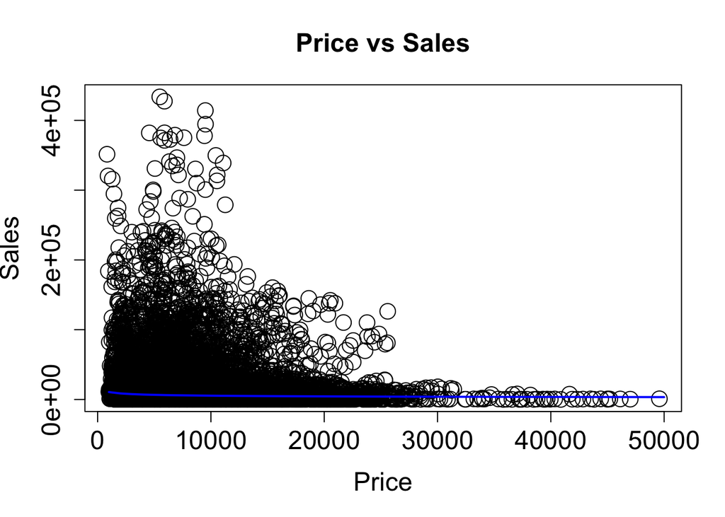

```r
#Scatterplot of prices and quantities
plot(cardata$eurpr,cardata$qu, main="Price vs Sales",
     xlab="Price", ylab="Sales", cex=2,cex.lab=1.5, cex.axis=1.5, cex.main=1.5, cex.sub=1.5)

#Add the regression line
pricespace=seq(0,50000,1000)
coef=reg1$coefficients
fitted=(exp(coef[1]+coef[2]*log(pricespace)))
lines(pricespace,fitted,col="blue",lwd=2)
```

Discovery 1. The regression line corresponds to the best linear predictor of sales quantity given price converted to Euros to represent price. in other words, exp(beta 0) is the demand (qu) when eurpr = 1

```r
#Adding fixed effect
reg2=felm(log(qu)~log(eurpr)|factor(co):factor(ye)+factor(ma),data=cardata)
summary(reg2)
```

```
##
## Call:
##    felm(formula = log(qu) ~ log(eurpr) | factor(co):factor(ye) +      factor(ma), data = cardata)
##
## Residuals:
##     Min      1Q  Median      3Q     Max
## -3.3171 -0.6045 -0.0718  0.5070  3.5261
##
## Coefficients:
##            Estimate Std. Error t value Pr(>|t|)
## log(eurpr)   -1.743      0.115  -15.15   <2e-16 ***
## ---
## Signif. codes:  0 '***' 0.001 '**' 0.01 '*' 0.05 '.' 0.1 ' ' 1
##
## Residual standard error: 1.066 on 8414 degrees of freedom
## Multiple R-squared(full model): 0.6846   Adjusted R-squared: 0.5716
## Multiple R-squared(proj model): 0.02657   Adjusted R-squared: -0.3224
## F-statistic(full model):6.056 on 3016 and 8414 DF, p-value: < 2.2e-16
## F-statistic(proj model): 229.7 on 1 and 8414 DF, p-value: < 2.2e-16
```

- Location and time fixed effects
  - ye: year(=first dimension of panel)
  - ma: market(=second dimension of panel)
  - co: model code (=third dimension of panel)

Here We add the interactive effects between market and car model and year as fixed effects. Contamination arises from over-time variations (year). Through the data set we found that some attributes for car models in different year changed, e.g. he and ac. We suspect that both car models and yearly demand variations cause causality issues, so we include the interactive fixed effects between both car model and time. Also, different markets likely have different underlying demand and hence the firm has been offering different prices. After adding the fixed effects, the absolute value of coefficient becomes greater than 1, which is more reasonable.

```r
#Add control variables
reg3=felm(log(qu)~log(eurpr)+loc+ac+he+engdpc|factor(co):factor(ye)+factor(ma),data=cardata)
summary(reg3)
```

```
##
## Call:
##    felm(formula = log(qu) ~ log(eurpr) + loc + ac + he + engdpc |      factor(co):factor(ye) + factor(ma), data = cardata)
##
## Residuals:
##     Min      1Q  Median      3Q     Max
## -3.4006 -0.5834 -0.0497  0.4897  3.5348
##
## Coefficients:
##              Estimate Std. Error t value Pr(>|t|)
## log(eurpr) -1.466e+00  1.444e-01 -10.153  < 2e-16 ***
## loc         7.378e-02  1.126e-02   6.552 6.11e-11 ***
## ac          1.765e-01  1.204e-02  14.658  < 2e-16 ***
## he          1.093e-01  3.972e-02   2.751  0.00595 **
## engdpc      7.002e-05  1.583e-05   4.422 9.92e-06 ***
## ---
## Signif. codes:  0 '***' 0.001 '**' 0.01 '*' 0.05 '.' 0.1 ' ' 1
##
## Residual standard error: 1.041 on 6832 degrees of freedom
##   (2267 observations deleted due to missingness)
## Multiple R-squared(full model): 0.7022   Adjusted R-squared: 0.6006
## Multiple R-squared(proj model): 0.06045   Adjusted R-squared: -0.2601
## F-statistic(full model):6.912 on 2331 and 6832 DF, p-value: < 2.2e-16
## F-statistic(proj model): 87.91 on 5 and 6832 DF, p-value: < 2.2e-16
```

- Control Variables
  - loc: location code (production side country where producer produce model)
  - ac: time to acceleration (in seconds from 0 to 100km/h, some from 0 to 96km/h)
  - he: height (in cm)

Here we first test several attributes related to product attributes and consumer tastes, such as location code, time to acceleration,average of fuel efficiency and so on. Then, we find that lots of variables have high p-value and are not significant. We drop those variables and only keep loc, ac, and he which are significant. Consumers might have preferences for where the car model were produced, the time to acceleration and the height of the car. We found that consumers prefer cars with larger height and longer time to acceleration, which indicates consumer may prefer low-mid price cars which have larger height and longer time to acceleration than extreme luxury sport cars

- engdpc: nominal GDP per capita in Euro (engdp/pop)

Also, we think that the macro environment and population also affects the purchasing power of consumers. Because price is also influenced by the inflation, here we want to use nominal GDP. The coefficient is positive, which means that with higher nominal GDP per capita in Euro, the sales quantity would be higher.

```r
# Add Instrumental Variables
reg=felm(log(qu)~loc+ac+he+engdpc|factor(co):factor(ye)+factor(ma)|(log(eurpr)~we*ironValue),data=cardata)
summary(reg)
```

```
##
## Call:
##    felm(formula = log(qu) ~ loc + ac + he + engdpc | factor(co):factor(ye) +      factor(ma) | (log(eurpr) ~ we * ironValue), data = cardata)
##
## Residuals:
##     Min      1Q  Median      3Q     Max
## -3.4085 -0.5964 -0.0315  0.5049  3.5969
##
## Coefficients:
##                     Estimate Std. Error t value Pr(>|t|)
## loc                7.090e-02  1.160e-02   6.111 1.05e-09 ***
## ac                 1.337e-01  1.730e-02   7.732 1.21e-14 ***
## he                 1.020e-01  4.087e-02   2.496   0.0126 *
## engdpc             1.989e-04  3.995e-05   4.979 6.54e-07 ***
## `log(eurpr)(fit)` -4.291e+00  8.134e-01  -5.276 1.36e-07 ***
## ---
## Signif. codes:  0 '***' 0.001 '**' 0.01 '*' 0.05 '.' 0.1 ' ' 1
##
## Residual standard error: 1.07 on 6832 degrees of freedom
##   (2267 observations deleted due to missingness)
## Multiple R-squared(full model): 0.6855   Adjusted R-squared: 0.5782
## Multiple R-squared(proj model): 0.007809   Adjusted R-squared: -0.3307
## F-statistic(full model):6.515 on 2331 and 6832 DF, p-value: < 2.2e-16
## F-statistic(proj model): 69.29 on 5 and 6832 DF, p-value: < 2.2e-16
## F-statistic(endog. vars):27.83 on 1 and 6832 DF, p-value: 1.362e-07
```

The amount of iron ore used to produce each car model is proportional to the weight. The prices of iron ore is the main input for car production. If the prices of iron ore increase, the input values of car will also increase, thus influence the prices of car. The iron ore price is highly related to costs. So, it’s a good IV here.

- we*ironValue: weight*prices of iron ore
  - Here we use the iron ore value times weight as the instrumental variable. The coefficient shifts from -1.46 to -4.29, which means that adding IV to the regression re-weight the price. iron ore value times weight is correlated with cost changes. The result with IV put more weights on changes in P that are highly correlated with cost changes.

## Part B : Recover costs

- Estimate the production cost of your rivals to assess the potential competitiveness of the market
- Find the pattern between price and costs

```r
#Demand function
reg=felm(log(qu)~loc+ac+he+engdpc|factor(co):factor(ye)+factor(ma)|(log(eurpr)~we*ironValue),data=cardata)
summary(reg)
```

```
##
## Call:
##    felm(formula = log(qu) ~ loc + ac + he + engdpc | factor(co):factor(ye) +      factor(ma) | (log(eurpr) ~ we * ironValue), data = cardata)
##
## Residuals:
##     Min      1Q  Median      3Q     Max
## -3.4085 -0.5964 -0.0315  0.5049  3.5969
##
## Coefficients:
##                     Estimate Std. Error t value Pr(>|t|)
## loc                7.090e-02  1.160e-02   6.111 1.05e-09 ***
## ac                 1.337e-01  1.730e-02   7.732 1.21e-14 ***
## he                 1.020e-01  4.087e-02   2.496   0.0126 *
## engdpc             1.989e-04  3.995e-05   4.979 6.54e-07 ***
## `log(eurpr)(fit)` -4.291e+00  8.134e-01  -5.276 1.36e-07 ***
## ---
## Signif. codes:  0 '***' 0.001 '**' 0.01 '*' 0.05 '.' 0.1 ' ' 1
##
## Residual standard error: 1.07 on 6832 degrees of freedom
##   (2267 observations deleted due to missingness)
## Multiple R-squared(full model): 0.6855   Adjusted R-squared: 0.5782
## Multiple R-squared(proj model): 0.007809   Adjusted R-squared: -0.3307
## F-statistic(full model):6.515 on 2331 and 6832 DF, p-value: < 2.2e-16
## F-statistic(proj model): 69.29 on 5 and 6832 DF, p-value: < 2.2e-16
## F-statistic(endog. vars):27.83 on 1 and 6832 DF, p-value: 1.362e-07
```

After knowing the demand function, we usually can calculate the optimal price of a firm with a given unit cost. Now that knowing the price, we are going to reverse-engineer this exercise to estimate the costs of rivals and have an idea about how rivals set prices optimally given their cost. In this way, we can assess the potential competitiveness of the market.

```r
# Compare among 5 years, same car model, same market
# Access the values of control variables and fixed effects

#For example, year 84, car model alfa 33, market 1
loc = cardata[cardata$ye == 84 & cardata$ma == 1 & cardata$type == "alfa 33", ]$loc
ac = as.numeric(cardata[cardata$ye == 84 & cardata$ma == 1 & cardata$type == "alfa 33", ]$ac)
he = as.numeric(cardata[cardata$ye == 84 & cardata$ma == 1 & cardata$type == "alfa 33", ]$he)
engdpc = cardata[cardata$ye == 84 & cardata$ma == 1 & cardata$type == "alfa 33", ]$engdpc

fe = getfe(reg)
idc <- match('1',fe$idx)
fe_ma=fe[idc,1]
idc <- match('1.84',fe$idx)
fe_coye=fe[idc,1]
```

```r
#Plug in the control variables and fixed effects in the demand function
demand = function(loc, ac, he, engdpc, fe_coye, fe_ma){
    demand = 0.0709*loc+0.1337*ac+0.102*he-0.0001989*engdpc+fe_coye+fe_ma

    return(demand)
}

constant = demand(loc, ac, he, engdpc, fe_coye, fe_ma)

#Optimize the profit with demand function by tuning the costs
profit = function(price){
    profit=-1*((price-4494)*exp(constant-4.291*log(price)))

    return(profit)
}

optim(5859.434082, profit)
```

```
## $par
## [1] 5859.434
##
## $value
## [1] -190790.5
##
## $counts
## function gradient
##       24       NA
##
## $convergence
## [1] 0
##
## $message
## NULL
```

At the cost of 4494, the optimal price = observed price = 5859.434082.  
Thus, the rival’s cost for car model alfa 33 in year 84 in market 1 is 4494.

```r
#Here is the table for year 84-88.
Years = c(84, 85, 86, 87, 88)
Markets = rep(1, 5)
CarModels = rep("alfa 33", 5)
Prices = c(5859.43, 6126.15, 6559.18, 7272.07, 7527.23)
Costs = c(4494, 4699, 5031, 5578, 5773)
differentYearsCosts = data.frame(Years, Markets, CarModels, Prices, Costs)
differentYearsCosts
```

```
##   Years Markets CarModels  Prices Costs
## 1    84       1   alfa 33 5859.43  4494
## 2    85       1   alfa 33 6126.15  4699
## 3    86       1   alfa 33 6559.18  5031
## 4    87       1   alfa 33 7272.07  5578
## 5    88       1   alfa 33 7527.23  5773
```

```r
#Compare among same year, same car model, 4 different markets

#For example, year 84, car model alfa 33, market 2
#Access the values of control variables and fixed effects
loc = cardata[cardata$ye == 84 & cardata$ma == 2 & cardata$type == "alfa 33", ]$loc
ac = as.numeric(cardata[cardata$ye == 84 & cardata$ma == 2 & cardata$type == "alfa 33", ]$ac)
he = as.numeric(cardata[cardata$ye == 84 & cardata$ma == 2 & cardata$type == "alfa 33", ]$he)
engdpc = cardata[cardata$ye == 84 & cardata$ma == 2 & cardata$type == "alfa 33", ]$engdpc

fe = getfe(reg)
idc <- match('2',fe$idx)
fe_ma=fe[idc,1]
idc <- match('1.84',fe$idx)
fe_coye=fe[idc,1]
```

```r
#Plug in the control variables and fixed effects in the demand function
demand = function(loc, ac, he, engdpc, fe_coye, fe_ma){
    demand = 0.0709*loc+0.1337*ac+0.102*he-0.0001989*engdpc+fe_coye+fe_ma

    return(demand)
}

constant = demand(loc, ac, he, engdpc, fe_coye, fe_ma)


#Optimize the profit with demand function by tuning the costs
profit = function(price){
    profit=-1*((price-5115)*exp(constant-4.291*log(price)))

    return(profit)
}

optim(6669.4, profit)
```

```
## $par
## [1] 6669.4
##
## $value
## [1] -428673.7
##
## $counts
## function gradient
##       24       NA
##
## $convergence
## [1] 0
##
## $message
## NULL
```

```r
#Table for 4 different markets.
Years = rep(84, 4)
Markets = c(1, 2, 4, 5)
CarModels = rep("alfa 33", 4)
Prices = c(5859.43, 6669.40, 7709.303, 7617.329)
Costs = c(4494, 5115, 5912.8, 5842)
differentMarketsCosts = data.frame(Years, Markets, CarModels, Prices, Costs)
```

```r
##Compare among same year, 4 different car models, same market
#For example, year 84, car model alfasud, market 1

#Access the values of control variables and fixed effects
loc = cardata[cardata$ye == 84 & cardata$ma == 1 & cardata$type == "alfasud", ]$loc
ac = as.numeric(cardata[cardata$ye == 84 & cardata$ma == 1 & cardata$type == "alfasud", ]$ac)
he = as.numeric(cardata[cardata$ye == 84 & cardata$ma == 1 & cardata$type == "alfasud", ]$he)
engdpc = cardata[cardata$ye == 84 & cardata$ma == 1 & cardata$type == "alfasud", ]$engdpc

fe = getfe(reg)
idc <- match('1',fe$idx)
fe_ma=fe[idc,1]
idc <- match('1.84',fe$idx)
fe_coye=fe[idc,1]
```

```r
#Plug in the control variables and fixed effects in the demand function
demand = function(loc, ac, he, engdpc, fe_coye, fe_ma){
    demand = 0.0709*loc+0.1337*ac+0.102*he-0.0001989*engdpc+fe_coye+fe_ma

    return(demand)
}

constant = demand(loc, ac, he, engdpc, fe_coye, fe_ma)

#Optimize the profit with demand function by tuning the costs
profit = function(price){
    profit=-1*((price-5573)*exp(constant-4.291*log(price)))

    return(profit)
}

optim(5850, profit)
```

```
## $par
## [1] 7266.511
##
## $value
## [1] -81118.79
##
## $counts
## function gradient
##       26       NA
##
## $convergence
## [1] 0
##
## $message
## NULL
```

```r
#Here is the table for 4 different markets.
Years = rep(84, 4)
Markets = rep(1, 4)
CarModels = c("alfa 33", "alfetta GTV","alfa giulietta", "alfasud")
Prices = c(5859.43, 8379.62, 7560.56, 7266.54)
Costs = c(4494, 6427, 5798, 5573)
differentCarModelsCosts = data.frame(Years, Markets, CarModels, Prices, Costs)
differentCarModelsCosts
```

```
##   Years Markets      CarModels  Prices Costs
## 1    84       1        alfa 33 5859.43  4494
## 2    84       1    alfetta GTV 8379.62  6427
## 3    84       1 alfa giulietta 7560.56  5798
## 4    84       1        alfasud 7266.54  5573
```

```r
#Patterns: price and cost

differentYearsCosts$cost_price_ratio = differentYearsCosts$Costs / differentYearsCosts$Prices

differentMarketsCosts$cost_price_ratio = differentMarketsCosts$Costs / differentMarketsCosts$Prices

differentCarModelsCosts$cost_price_ratio = differentCarModelsCosts$Costs / differentCarModelsCosts$Prices

print(differentYearsCosts)
```

```
##   Years Markets CarModels  Prices Costs cost_price_ratio
## 1    84       1   alfa 33 5859.43  4494        0.7669688
## 2    85       1   alfa 33 6126.15  4699        0.7670397
## 3    86       1   alfa 33 6559.18  5031        0.7670166
## 4    87       1   alfa 33 7272.07  5578        0.7670443
## 5    88       1   alfa 33 7527.23  5773        0.7669488
```

```r
print(differentMarketsCosts)
```

```
##   Years Markets CarModels   Prices  Costs cost_price_ratio
## 1    84       1   alfa 33 5859.430 4494.0        0.7669688
## 2    84       2   alfa 33 6669.400 5115.0        0.7669356
## 3    84       4   alfa 33 7709.303 5912.8        0.7669695
## 4    84       5   alfa 33 7617.329 5842.0        0.7669355
```

```r
print(differentCarModelsCosts)
```

```
##   Years Markets      CarModels  Prices Costs cost_price_ratio
## 1    84       1        alfa 33 5859.43  4494        0.7669688
## 2    84       1    alfetta GTV 8379.62  6427        0.7669799
## 3    84       1 alfa giulietta 7560.56  5798        0.7668744
## 4    84       1        alfasud 7266.54  5573        0.7669400
```

A specific pattern we found is that the cost-price ratio (cost/price) is 76.7% across years, markets, and car models.  
This means that the demand is reasonable cause car companies will want to keep their products profitable for each car type though some type might have larger costs. Last but not least, 76.7% is a reasonable profitable ratio for low to middle price cars based on the reference of Toyota’s 2021 gross margin.

## Part C : Calculate Cross-elasticities and competitive effects

- Consider cross-price elasticities in the log-log regression

```r
#Include prices of rival cars
reg7 = felm(log(qu)~log(avgurprrival)
           +loc+ac+he+engdpc|factor(co):factor(ye)+factor(ma)|(log(eurpr)~we*ironValue),data=cardata)
summary(reg7)
```

```
##
## Call:
##    felm(formula = log(qu) ~ log(avgurprrival) + loc + ac + he +      engdpc | factor(co):factor(ye) + factor(ma) | (log(eurpr) ~      we * ironValue), data = cardata)
##
## Residuals:
##     Min      1Q  Median      3Q     Max
## -3.1389 -0.5754 -0.0481  0.4839  3.5092
##
## Coefficients:
##                     Estimate Std. Error t value Pr(>|t|)
## log(avgurprrival)  4.635e+00  6.762e-01   6.855 7.73e-12 ***
## loc                8.469e-02  1.127e-02   7.516 6.39e-14 ***
## ac                 1.268e-01  1.753e-02   7.234 5.19e-13 ***
## he                 1.051e-01  3.952e-02   2.659  0.00784 **
## engdpc            -3.818e-06  1.907e-05  -0.200  0.84129
## `log(eurpr)(fit)` -4.224e+00  7.869e-01  -5.367 8.25e-08 ***
## ---
## Signif. codes:  0 '***' 0.001 '**' 0.01 '*' 0.05 '.' 0.1 ' ' 1
##
## Residual standard error: 1.035 on 6831 degrees of freedom
##   (2267 observations deleted due to missingness)
## Multiple R-squared(full model): 0.7056   Adjusted R-squared: 0.6052
## Multiple R-squared(proj model): 0.07125   Adjusted R-squared: -0.2458
## F-statistic(full model):6.969 on 2332 and 6831 DF, p-value: < 2.2e-16
## F-statistic(proj model): 66.54 on 6 and 6831 DF, p-value: < 2.2e-16
## F-statistic(endog. vars):28.81 on 1 and 6831 DF, p-value: 8.255e-08
```

- Discovery:
  - The coefficient of log(avgurprrival) represents if the average rival price changes 1%,the quantity of my products would change caused what percentage, which also represents cross price elasticity of demand. In this regression, the coefficient means the sales of my products would increase about 4.6% if the average rival price increase 1%.
  - I expect a positive coefficient of the rival price,since the percentage increase of rival price should increase our sales somehow. So, the estimated coefficient fulfills my expectation in this aspect. But i also expect the coefficient of rival price would eliminate some contamination from the coefficient of our price. So,by adding average rival price, the coefficient of our price should change. But it doesn’t change much, which means the log(avgurprrival) doesn’t take the non-causal variations away from the coefficient of out price.
  - The estimated coefficient tell us that the competitiveness of the market is fierce, since the absolute value of coefficient of rival price and our price are almost the same, and the change of rivals’ price change has big impact on our demand. So, the competitiveness of market is fierce.